# EndPoints CTL08: Main Gene Signatures

## 3. Selecting and filtering

### 3.1 Sample Selection

Already performed.

### 3.2 Gene Filtering

#### 3.2.1 Setting gene filtering thresholds

```r
CpmFilt <- params$CpmFilt
if(is.numeric(CpmFilt)==FALSE){
  stop('ERROR! Cpm threshold for gene filtering has a non-numeric value')
}

SampleFilt <- ifelse(params$SampleFilt=='Default', dim(SE_Bio)[2]/2, params$SampleFilt)
if(is.numeric(SampleFilt)==FALSE){
  stop('ERROR! Sample threshold for gene filtering has a non-numeric value')
}
```

**Genes having an expression lower than 2 in at least 4 samples are filtered out.**

#### 3.2.2 Filter out low expressed genes

- Compute temporary cpm (without TMM normalization, not stored in SE)
- Filter out lowly-expressed genes

```r
SE_Bio$lib.size
##        S32829_H12_DMSO      S32830_H14_Ret_Ag      S32831_H15_Ret_Ag
##               35613673               59279739               70826142
##    S32833_H27_Thyr_Inh    S32837_H35_LivX_Inh    S32838_H36_LivX_Inh
##               67049867               56634424               68940854
##     S32839_H38_LivX_Ag     S32840_H39_LivX_Ag     S32841_H41_Estr_Ag
##               53964028               36461411               63518569
##     S32842_H42_Estr_Ag     S32845_H51_Andr_Ag    S32846_H52_Andr_Inh
##               42604865               45209919               85402393
##    S32847_H53_Andr_Inh    S32848_H54_Andr_Inh      S32849_H60_GC_Inh
##               64432453               30728121               76458966
##   S32853_H68_AhHyd_Inh   S32854_H69_AhHyd_Inh     S32857_H22_Thyr_Ag
##               79053007               28308197               51578374
##    S32858_H25_Thyr_Inh         S32860_H9_DMSO     S32861_H17_Ret_Inh
##               69682372               54069427               68212493
##     S32862_H18_Ret_Inh      S32864_H13_Ret_Ag     S32865_H23_Thyr_Ag
##               35022905               27114632               36213800
##       S35870_MTR3_DMSO   S35872_MTR5_Thyr_Inh   S35875_MTR8_LivX_Inh
##               33548410               48558405               56970827
##    S35876_MTR9_LivX_Ag   S35879_MTR12_Andr_Ag    S35881_MTR14_GC_Inh
##               52549588               40765101               55221358
## S35882_MTR15_AhHyd_Inh          MTR16_S34_CTL          MTR17_S38_CTL
##               52843891               29163508               35691834
##          MTR19_S41_CTL          MTR20_S48_CTL          MTR21_S29_CTL
##               38249382               23658993               38700856
##         MTR22_S46_DMSO         MTR23_S28_DMSO         MTR24_S51_DMSO
##               36339476               31756335               28625488
##         MTR25_S43_DMSO         MTR26_S33_DMSO      MTR27_S53_Thyr_Ag
##               32823794               29031507               36025706
##      MTR28_S50_Thyr_Ag      MTR29_S30_Andr_Ag      MTR30_S42_Andr_Ag
##               36156859               38661303               37547288
##        MTR31_S47_GC_Ag        MTR32_S35_GC_Ag        MTR33_S37_GC_Ag
##               39385341               31560063               23287199
##     MTR37_S52_AhHyd_Ag     MTR38_S44_AhHyd_Ag     MTR39_S49_AhHyd_Ag
##               33521688               34704497               32385629
SE_Filt <- filterSE(SE_Bio, cpmTh=CpmFilt, sampleTh=SampleFilt)
## UPDATED library.size slot
```

#### 3.2.3 Normalize

- Re-calculate library size and calculate TMM
- Calculate cpm and logcpm (with normalization) and store in SE_Filt
- Calculate Fpkm and logfpkm

```r
SE_Filt <- normTmmSE(SE_Filt, useNormFactors=TRUE, priorCount=0.25)

assays(SE_Filt)$fpkm <- edgeR::rpkm(SE_Filt, normalized.lib.sizes = TRUE, gene.length=rowData(SE_Filt)$GeneLength)
assays(SE_Filt)$logfpkm <- edgeR::rpkm(SE_Filt, normalized.lib.sizes = TRUE, gene.length=rowData(SE_Filt)$GeneLength,
                                  log=TRUE, prior.count=0.25)
```

**After filtering out lowly-expressed genes, the dataset is structured in 14213 genes measured in 51 samples.**

## 4. Heatmaps: pre-processing

### 4.1 Gene name as row names

```r
rownames(SE_Filt) <- rowData(SE_Filt)$GeneName
SE_Filt <- SE_Filt[!duplicated(rownames(SE_Filt)), ]
```

### 4.2 Calculate the fold-change

Calculate the fold-change compared to the controls (DMSO). This is done on logcpm.

```r
DMSO <- as.vector(which(SE_Filt$Condition=='DMSO'))
SE_Filt <- SEtools::log2FC(SE_Filt, fromAssay='logcpm', controls=DMSO, isLog=TRUE, toAssay='log2FC')
```

### 4.3 Define the color annotation

```r
colData(SE_Filt)$Condition <- factor(colData(SE_Filt)$Condition, levels=c("CTL", "DMSO", "AhHyd_Ag", "AhHyd_Inh", "Andr_Ag", "Andr_Inh", "Estr_Ag", "Estr_Inh", "GC_Ag", "GC_Inh", "LivX_Ag", "LivX_Inh", "Ret_Ag", "Ret_Inh", "Thyr_Ag", "Thyr_Inh" ))

metadata(SE_Filt)$anno_colors <- list(Condition = c('DMSO' = 'grey30', 'CTL' = 'azure3',

                 'AhHyd_Ag'='#F8766D', 'AhHyd_Inh'='#F8766D50',

                 'Andr_Ag'='#fccb17', 'Andr_Inh'='#C49A0050',

                 "Estr_Ag"= '#53B400', "Estr_Inh"= '#53B40050',

                 'GC_Ag' = '#00C094', 'GC_Inh' = '#00C09450',

                 'LivX_Ag' = '#00B6EB', 'LivX_Inh' = '#00B6EB50',

                 'Ret_Ag' = '#A58AFF', 'Ret_Inh' = '#A58AFF50',

                 'Thyr_Ag' = '#FB61D7', 'Thyr_Inh' = '#FB61D750'

                 )
 , SeqRun = c("20210310" = "orange", "20210724"  = "green4", "20220422" =
                                          "#66ACB7"))
```

## 5. Heatmaps

### 5.1 Gene signature

```r
Genes <- GS %>% dplyr::pull(GeneName)

Genes[! Genes %in% row.names(SE_Filt)]
##  [1] "ORC1  "   "DLX1"     "DLX2"     "DLX6-AS1" "NKX2-1"   "ETNPPL"
##  [7] "RANBP3L"  "SERPINC5" "KLK6"     "APOD"

rowData(SE_Filt)$Signatures <- NA
for (i in which(rowData(SE_Filt)$GeneName %in% Genes)){
  gene <- row.names(SE_Filt)[i]
  rowData(SE_Filt)[i, 'Signatures'] <-GS[GS$GeneName==gene, "Population"]
}

#color for signatures
rowData(SE_Filt)$Signatures <- factor(rowData(SE_Filt)$Signatures, levels=c("Cycling", "NSC", "ApicalProg", "IntermProg", "oRG", "PanNeuron", "ExcN", "InhN", "LowLayerN", "UpLayerN", "PostSynaptic", "Astrocyte", "Oligo"))

metadata(SE_Filt)$anno_colors$Signatures <- c(ApicalProg = "#e6194b", Astrocyte = "#4363d8", Cycling = "#46f0f0", ExcN = "#e6beff", InhN = "#9a6324", IntermProg = "#aaffc3", LowLayerN = "#000075", NSC = "#84b37d", Oligo = "#9a499a", oRG = "#f2802c", PanNeuron = "#4ba0be", PostSynaptic = "#dff3e4", UpLayerN = "#b2ec94")

#color for heatmaps
ScaledCols <- c('darkblue', "purple","white","lightgoldenrod1", 'goldenrod1')
```

**The following genes are not selected as expressed:** ORC1 , DLX1, DLX2, DLX6-AS1, NKX2-1, ETNPPL, RANBP3L, SERPINC5, KLK6, APOD.

### 5.2 Expression levels: logfpkm without scaling

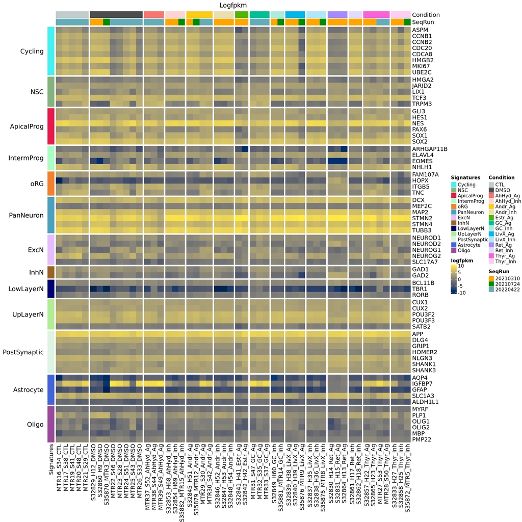

```r
break_coord <- assays(SE_Filt[row.names(SE_Filt) %in% Genes, ])$logfpkm %>% quantile(seq(0,1, by=0.1))
ExpCols <- viridisLite::cividis(length(seq(head(break_coord,1), tail(break_coord,1), by=0.2)))

p1 <- sechm::sechm(SE_Filt, features=Genes, assayName="logfpkm", gaps_at = "Condition", gaps_row="Signatures", top_annotation = c("Condition", "SeqRun"), show_rownames = TRUE, left_annotation = c("Signatures"), sortRowsOn=NULL, cluster_rows=FALSE, cluster_cols = FALSE,  show_colnames=TRUE, hmcols=ExpCols, breaks=seq(head(break_coord,1), tail(break_coord,1), by=0.2), column_title = "Logfpkm", row_title_rot = 0)
# breaks FALSE to avoid a symmetrical scale
p1
```

Saving to PDF file

### 5.3 Expression levels: scaled logfpkm

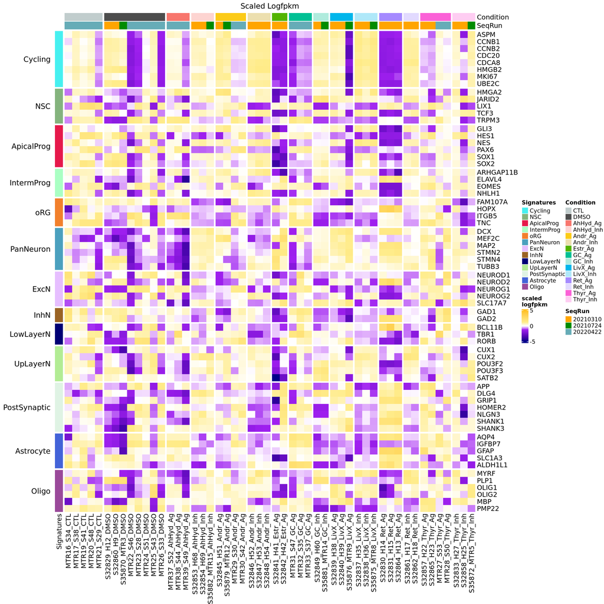

```r
p2 <- sechm::sechm(SE_Filt, features=Genes, assayName="logfpkm", gaps_at = "Condition", gaps_row="Signatures", top_annotation = c("Condition", "SeqRun"), show_rownames = TRUE, left_annotation = c("Signatures", "UpregulatedBy", "DownregulatedBy"), sortRowsOn=NULL, cluster_rows=FALSE, cluster_cols = FALSE,  show_colnames=TRUE, hmcols=ScaledCols, do.scale=TRUE, breaks=0.8, column_title = "Scaled Logfpkm", row_title_rot = 0)
p2
```

Saving to PDF file

### 5.4 Expression levels: Log2FC versus DMSO

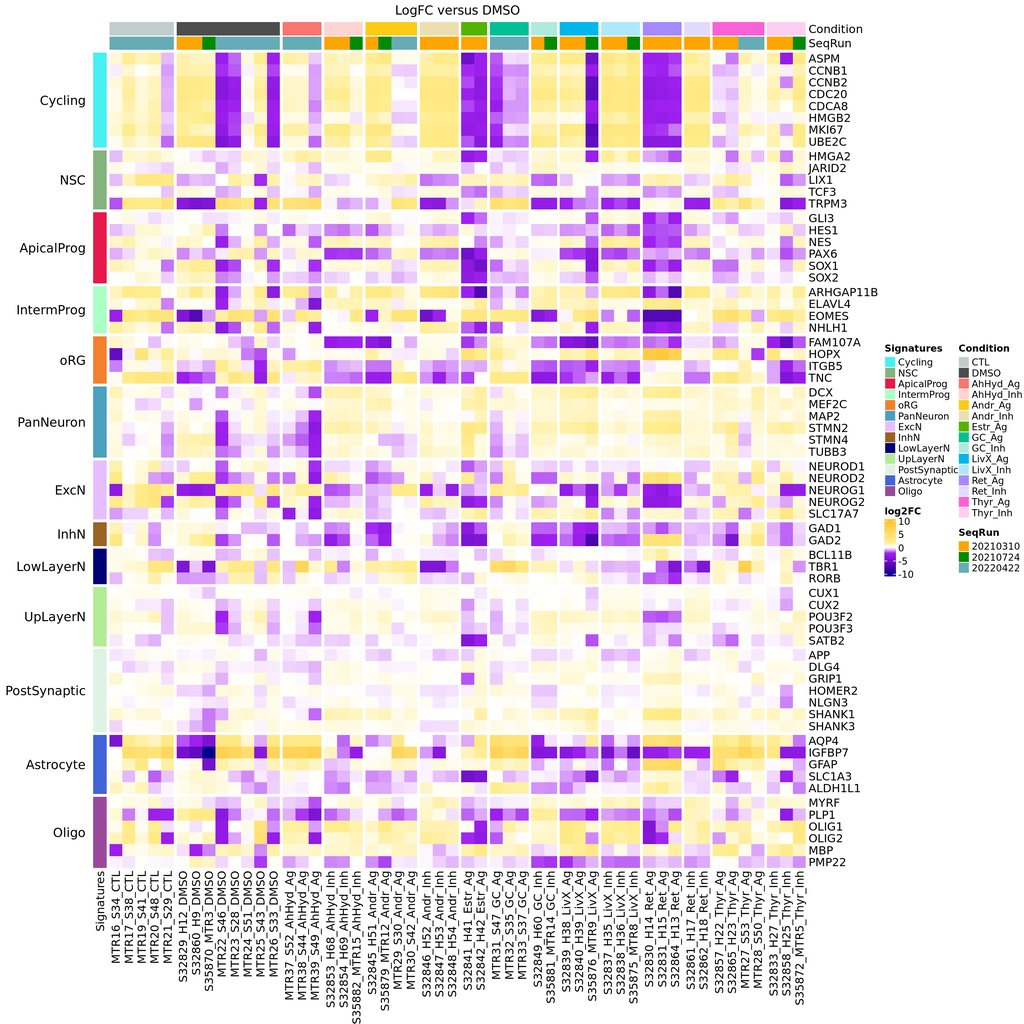

```r
p3 <- sechm::sechm(SE_Filt, features=Genes, assayName="log2FC", gaps_at = "Condition", gaps_row="Signatures", top_annotation = c("Condition", "SeqRun"), show_rownames = TRUE, left_annotation = c("Signatures", "UpregulatedBy", "DownregulatedBy"), sortRowsOn=NULL, cluster_rows=FALSE, cluster_cols = FALSE,  show_colnames=TRUE, hmcols=ScaledCols,
      do.scale=FALSE, breaks = 0.85, column_title = "LogFC versus DMSO", row_title_rot = 0)
p3
```

Saving to PDF file

## 6. Savings

```r
SessionInfo <- sessionInfo()
Date <- date()
save.image(paste0(OutputFolder, '/', Dataset, 'SigMain_Workspace.RData'))
```

```r
Date
```

```
## [1] "Fri Jul 18 13:26:19 2025"
```

```r
SessionInfo
```